# Babe Ruthe Stattistics

[figure not shown]

[figure not shown]

[figure not shown]

George Herman “Babe” Ruth Jr. was a professional baseball player whose career in Major League Baseball spanned 22 seasons, from 1914 through 1935. He played for the Boston Red Sox (1914-1919), New York Yankees (1920-1934), and Atlanta Braves (1935). He was a power hitter for New York Yankies in 20’s & 30’s. Babe held the recod for most HR in a season in 1919 with the Boston Red Sox, he broke his own record 3 times.  
In 1927 he hit 60 Homeruns in one season. This record held until Roger Maris of the NYY broke it in 1961.

As a side note, I was nine & remember this being being news, watching a replay of hit number 715 on the nightly news. That spring, all the boys at school talked about was baseball & “when” he would break the record.

### Strikeous vs Home Runs(scatter plot graph)

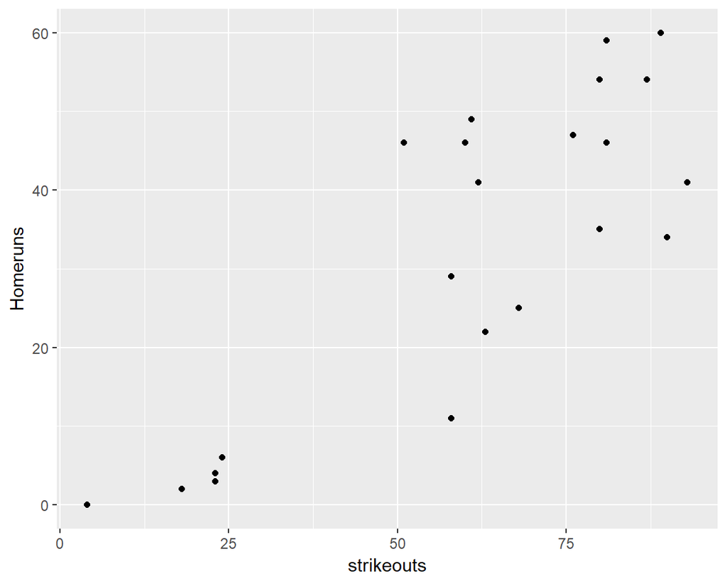

### Picture from Web

[figure not shown]

### Homerun distribution (histogram plot)

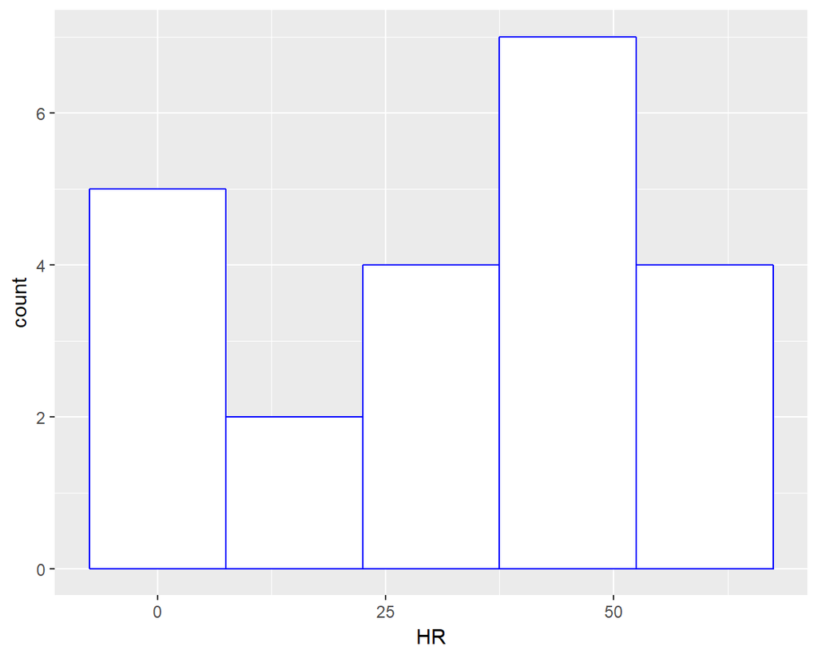

### Homerun totals each year (line plot)

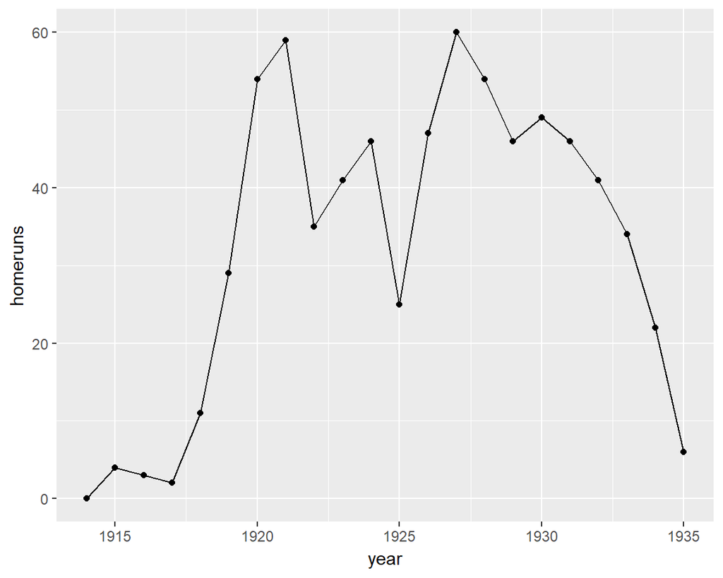

end